# Death Penalty and Gun Control

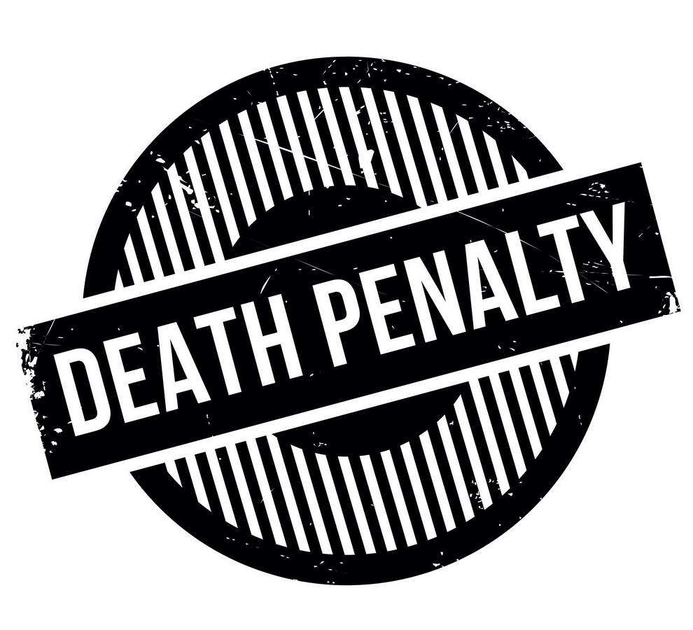

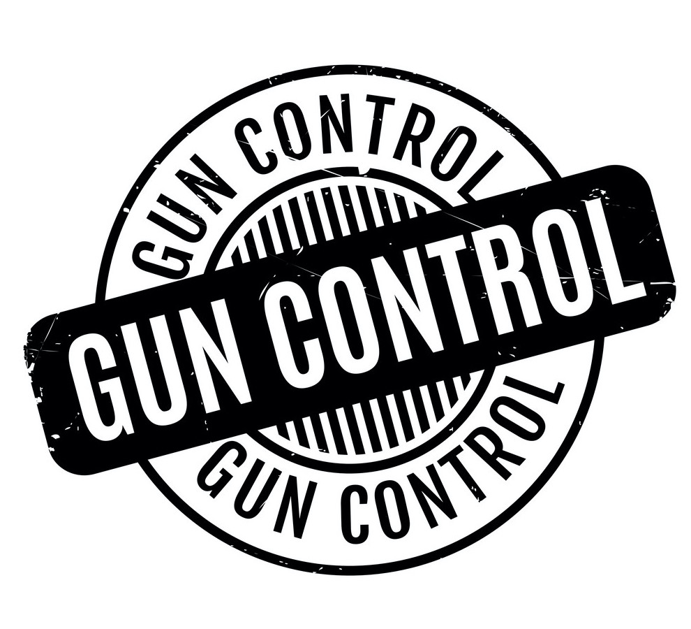

## Introduction

Death penalty and gun control have always been politicized during election seasons. It would be interesting to shift attention away from the politicians and investigate voters’ thoughts. In this project, I want to explore and answer the following questions:

- Over the years, did voters’ attitude alter?
- Is there a connection between voters’ party identification and attitude toward these two topics?
- Would being Conservative or Liberal affect voters’ attitude toward these two topics?

## Time Trend

To discover the respondents’ opinion on death penalty, I analyzed the responses to the survey question “Do you favor or oppose the death penalty for persons convicted of murder?” that was added to the ANES survey since 1988. According to the following chart, there are always more votes who favor such punishment for crime than those who oppose it. (The peak in 2012 is due to increased sample size.)

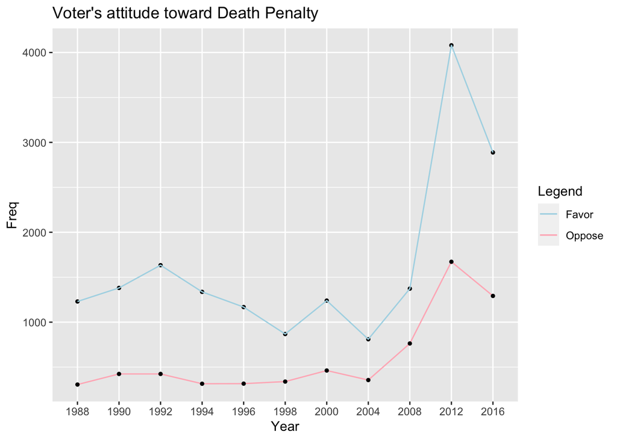

I analyzed the responses’ attitude to gun control from 2000 to 2016. Not many voters want to ease the gun control. There are more votes who favor stricter firearm policy than those who oppose any gun policy changes. The difference, though, is much smaller than in the previous case. This is probably why the gun control remains a controversial issue.

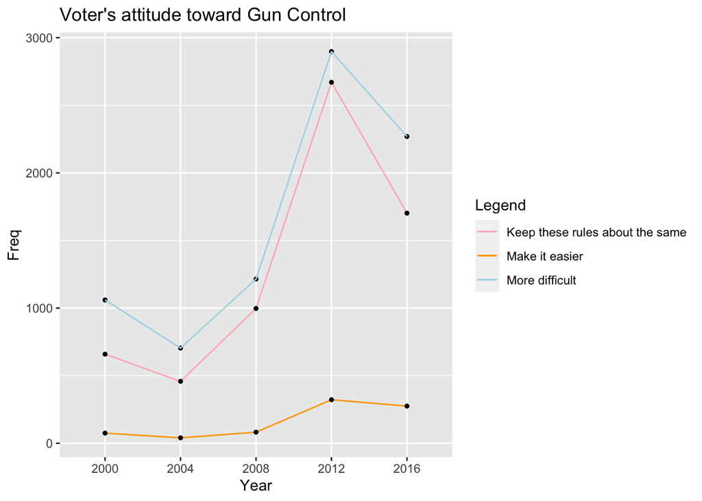

## Party Identifications

Would the party identification of a voter affect his opinion? In the chart below, more voters support death penalty than against it disregarding of the party identification. A strong majority of Republicans support the death penalty while over one third of Democrats oppose it. In other words, Democrats are more likely to oppose death penalty than Republicans do and Republicans are more likely to support it than Democrats do.

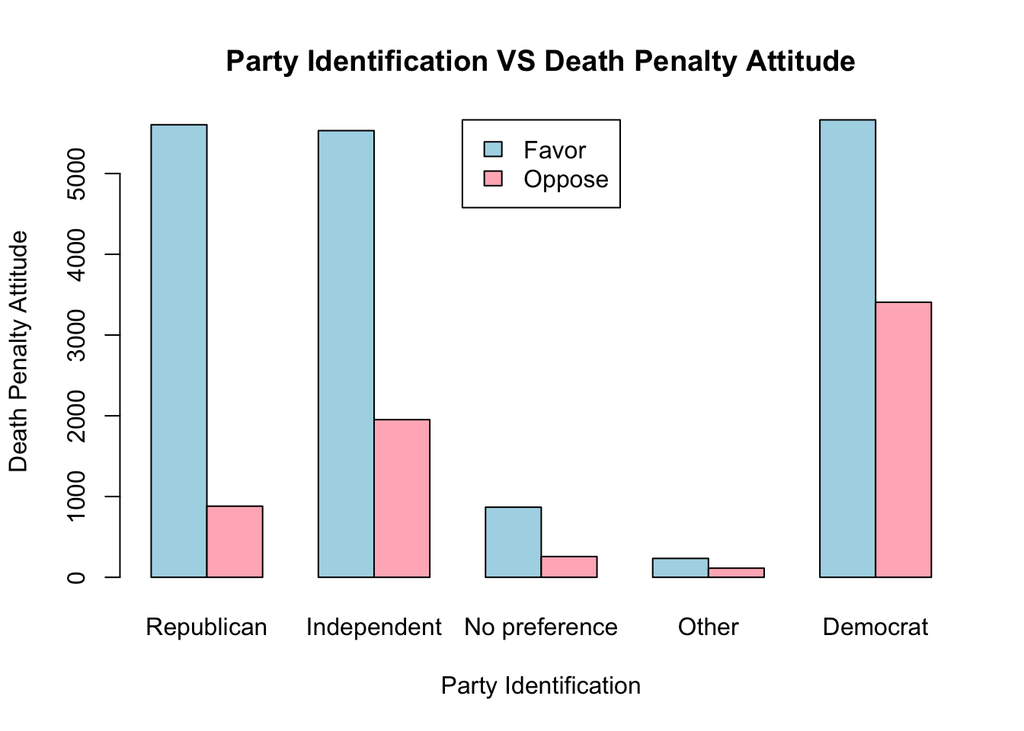

When it comes to gun control issue, different parties have variate thoughts. The majority of Republicans want to keep the gun policy as it is. The amount of Independent(no preference and other also) voters who want to keep the rules the same is roughly the same to that of those who want to make the rule stricter. A strong majority of Democrats prefer making the gun control more difficult. In all parties, a minority of votes likes to ease the gun policies.

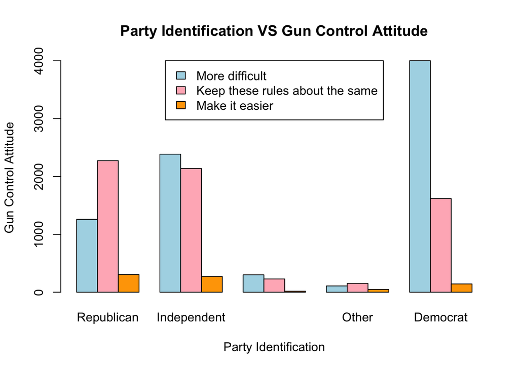

## Conservative or Liberal

For the last part, let’s see whether being liberal or conservative would affect voters’ attitude. No matter the voters are Liberal, Moderate or Conservative, the majority prefer favoring the death penalty. Liberal voters are more likely to oppose the death penalty than others. On the other hand, Conservative are least likely to oppose death penalty.

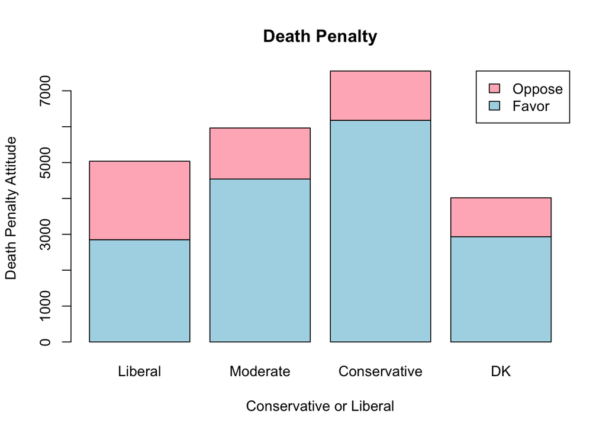

In the case of gun control, Conservatives tend to keep the gun policy the same while the Liberals tend to tighten the gun policy. In other words, Conservatives and Liberals are take different sides on the gun control issue. Regardless of being Liberal or whatsoever, not many voters like to loosen the gun policy.

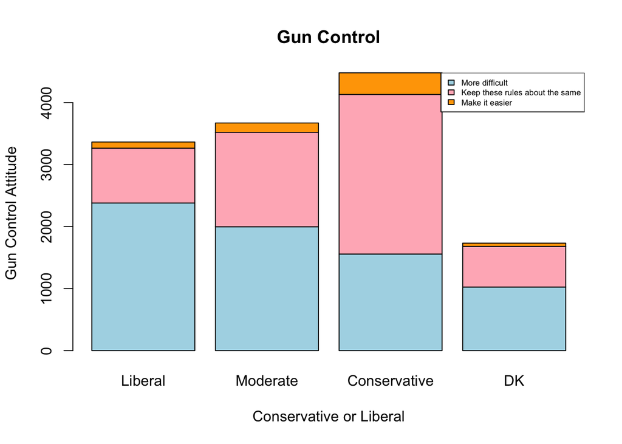